# Session 7: Content-Based Methods

> *"The set of documents in a collection then may be viewed as a set of vectors in a vector space, in which there is one axis for each term."* — Manning, Raghavan & Schütze, *Introduction to Information Retrieval* (Cambridge UP, 2008), Ch. 6

**Core idea:** describe every item *and* every user as a vector of features, then let **angle and distance** decide what is similar.

## What is a vector?

A vector is just a list of numbers that describes something.  
If we have two numbers, we can draw it as a point in 2D.

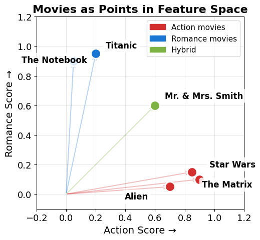

```
Similar movies are CLOSE in this space. That's the whole idea.
```

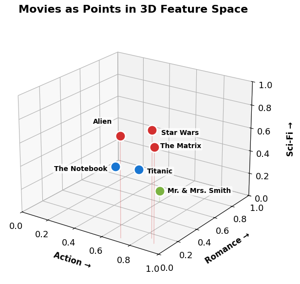

```
Action movies (red) cluster at high Action + Sci-Fi; romances (blue) sit on the floor (Sci-Fi = 0).
```

## From 2 features to 3 … to hundreds

Two numbers → a point in 2D. Add a third feature (**Sci-Fi**) and the same movies spread out in 3D.

The math never cares how many axes there are — a movie with 20 genres is just a point in 20-dimensional space. We simply can't *draw* past three.

## Building the Item-Feature Matrix

Each movie has genres. We turn them into a **binary vector** (one-hot encoding).

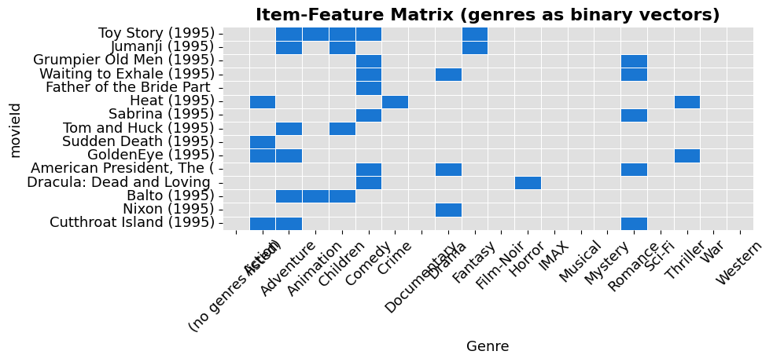

```
Each movie is a vector with 20 dimensions (one per genre).
```

### Seeing all of them at once

We can't plot 20 genre-dimensions, so we **project** every movie down to 2D with PCA — neighbours in this picture really are similar in genre space.

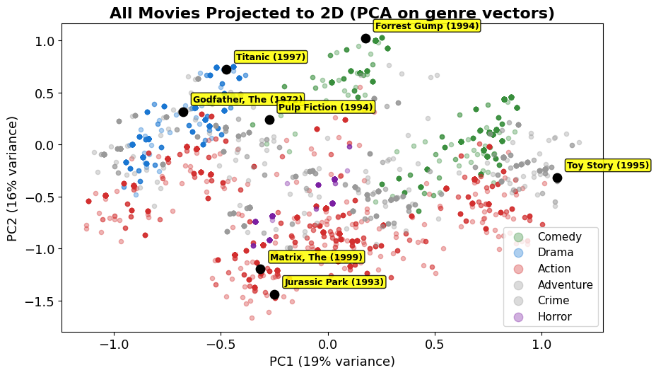

```
Similar genre profiles → close in space. But 2D is a rough approximation of 20 dimensions.
```

## Beyond genres: richer movie vectors

We started with just **genre flags** (~20 dimensions). Real recommenders add **whatever signal helps**:

| Source | Example features |
| --- | --- |
| **Cast & crew** | director, lead actors, composer, cinematographer |
| **Plot keywords** | "time travel", "heist", "based on true story" |
| **Metadata** | year, runtime, country, MPAA rating |
| **User signals** | tags, average rating, popularity |

Every new feature is **another dimension** of the same vector. Two movies sharing the same director or composer become close even if their genres differ — capturing the kind of "more of the same" that genres alone miss.

*(More dimensions = more nuance, but also the curse of dimensionality. Watch for that in a few slides.)*

## Users are vectors too

Describe each user with the **same feature axes** as the items. Then a recommender is just: "find items whose vector points the same way as this user's."

A user vector can come from a **questionnaire**, the **average of items they watched/clicked**, or **feature extraction** over their history.

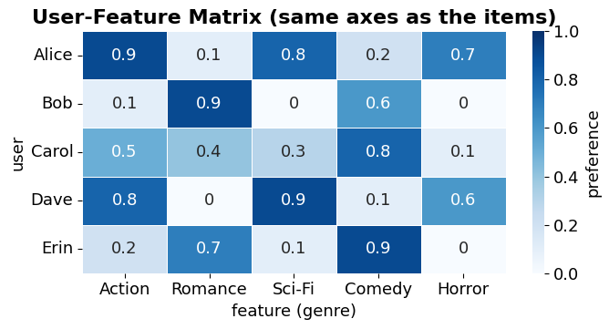

```
Alice and Dave both love Action + Sci-Fi -> their vectors point the same way -> similar taste.
```

## Comparing Vectors: Dot Product

Multiply matching components, then sum — both as an algebraic recipe and a geometric identity:

$$\vec{a}\cdot\vec{b} \;=\; \sum_i a_i\,b_i \;=\; \lVert\vec{a}\rVert\,\lVert\vec{b}\rVert\,\cos(\theta)$$

**Worked example.** With $\vec{a} = (3,\,1,\,2)$ and $\vec{b} = (1,\,4,\,2)$:

$$\vec{a}\cdot\vec{b} \;=\; 3{\cdot}1 + 1{\cdot}4 + 2{\cdot}2 \;=\; \boxed{\,11\,}$$

And the **length** (Euclidean norm, used in every formula below) of a vector:

$$\lVert\vec{a}\rVert \;=\; \sqrt{\textstyle\sum_i a_i^{\,2}} \;=\; \sqrt{3^2 + 1^2 + 2^2} \;=\; \sqrt{14} \;\approx\; 3.74$$

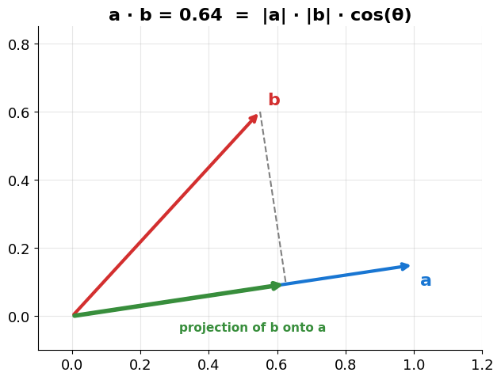

```
A longer b gives a bigger dot product at the same angle. Cosine divides by both lengths, so only the angle survives.
```

## Cosine Similarity: dot product, length removed

Take the dot-product identity and **isolate the angle** — move everything except $\cos(\theta)$ to the right side:

$$\vec{a}\cdot\vec{b} \;=\; \lVert\vec{a}\rVert\,\lVert\vec{b}\rVert\,\cos(\theta) \quad\Longrightarrow\quad \boxed{\;\cos(\theta) \;=\; \dfrac{\vec{a}\cdot\vec{b}}{\lVert\vec{a}\rVert\,\lVert\vec{b}\rVert}\;}$$

So **cosine similarity = dot product after normalising both vectors to length 1** — it ignores magnitude, only the angle remains.

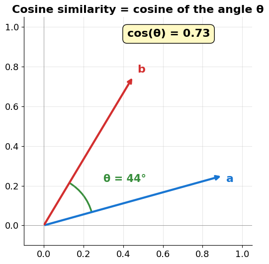

### What the number actually means

Same reference vector, swept from 0° to 180°. Cosine **starts at 1** (identical direction), is **0** at a right angle, and reaches **−1** when the vectors point opposite ways.

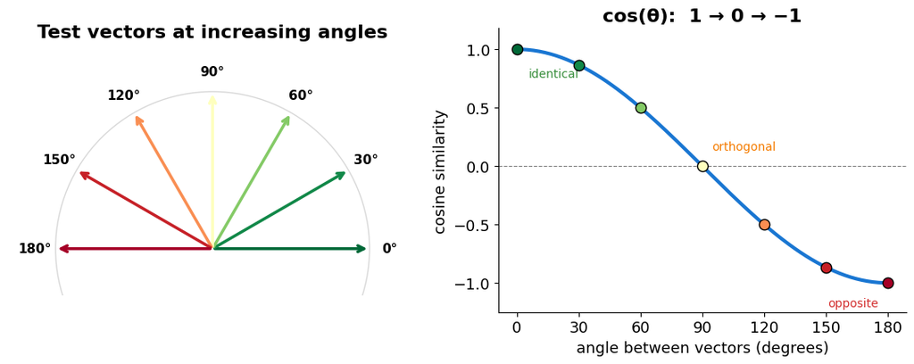

### Cosine on movie-like vectors: three cases

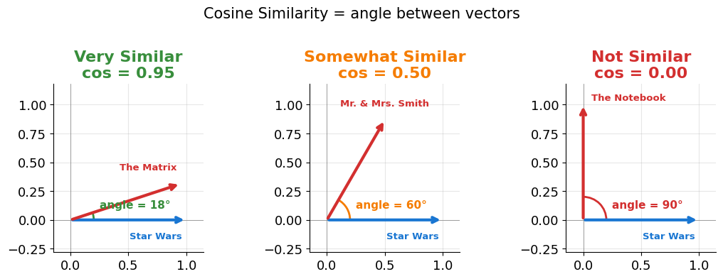

## Euclidean Distance = the straight-line gap

**Algebraic form** (works in any number of dimensions):

$$d(\vec{a},\vec{b}) \;=\; \sqrt{\sum_i (a_i - b_i)^2}$$

Forget angles — just measure the **distance between the two points**.

Small distance = similar.

(As a *similarity* score we often use $-d$, since closer should mean "more similar".)

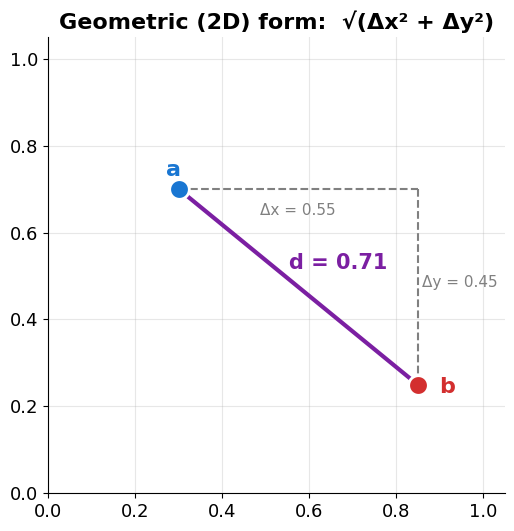

## Manhattan Distance = the city-block path

$$d_{1}(\vec{a},\vec{b}) \;=\; \sum_i |a_i - b_i|$$

Instead of the diagonal hypotenuse, **sum the absolute differences** — as if you can only walk along the grid, N/S or E/W. Manhattan ≥ Euclidean always (the diagonal is shorter than the L-shape).

In **high-dimensional, sparse** vectors (where most coordinates are zero) L1 is often the more robust choice for nearest-neighbour search — no squaring means fewer dimensions dominate the score.

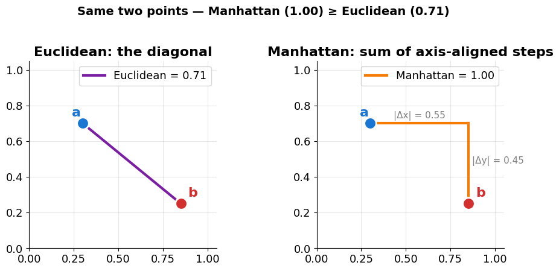

```
Manhattan = L1 norm of (a - b); Euclidean = L2. In high-D, L1 is often the more robust choice.
```

## Summary: Cosine vs. Euclidean vs. Dot Product vs. Manhattan

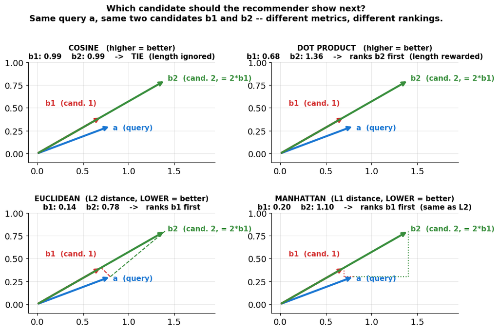

### When to use which measure

| Measure | Best for | Why |
| --- | --- | --- |
| **Cosine** | text, tags, bag-of-words — anywhere **lengths vary** | only angle counts, so a 10-word and a 1000-word doc compare fairly |
| **Dot product** | recommender scores (e.g. matrix factorisation) | rewards **both** alignment and confidence/length |
| **Euclidean (L2)** | dense vectors where **magnitude is meaningful** | straight-line gap; squaring amplifies large differences |
| **Manhattan (L1)** | high-dim **sparse, non-learned** vectors (raw TF-IDF, counts) | no squaring, so fewer single dims dominate — a *rule of thumb* (Aggarwal et al. 2001), not a law |

**Pick the metric by where the vectors came from — not by their dimensionality:**

- **Learned embeddings** (sentence transformers, …) → use the metric they were *trained* with, almost always **cosine / dot** — at 384 *or* 4096 dims. Don't switch to L1 just because it's high-dimensional.
- **Sparse, non-learned** vectors (TF-IDF, counts) → **cosine**; L1 is worth a try in very high dimensions.

**Normalise and the distinction often vanishes:** for unit vectors $\lVert\vec a-\vec b\rVert_2^2 = 2 - 2(\vec a\cdot\vec b)$, so cosine, dot product, and Euclidean rank neighbours in the **identical** order.

## The Curse of Dimensionality

Genre vectors live in ~20 dimensions; real feature vectors can have **thousands**. As dimensionality grows, something counter-intuitive happens to distance.

**The phenomenon.** Beyer et al. (1999) proved that for a wide class of distributions, as $d \to \infty$ the ratio of the **farthest** to the **nearest** neighbour of a query point tends to $1$. In very high dimensions *every* point is roughly the same distance from every other point — so "nearest neighbour" loses its meaning.

**Geometric intuition.** Fix the unit cube $[0,1]^d$. Two things happen as $d$ grows:

- The inscribed unit ball's volume shrinks toward $0$ — almost all the cube's mass sits **in the corners**, not near the centre.
- Almost all of a $d$-ball's volume concentrates in a **thin shell** at the boundary, so two random points have nearly the same radius and their pairwise distances bunch into a narrow band.

**Why cosine survives better — with caveats.** Cosine isn't immune: for **dense** random vectors in high $d$, every pair becomes nearly orthogonal (cos $\approx$ 0) and the curse hits it too. But the vectors used in content-based recommending — TF-IDF, tag indicators, one-hot features — are **sparse**: similarity is driven by the handful of dimensions where both vectors are non-zero. That handful carries the signal; the many shared zeros are silent (they neither add to the numerator nor distort the angle), whereas in Euclidean distance every dimension contributes a small `0−ε` term and the noise piles up. Discarding magnitude also removes one source of variation that carries no meaning for count-style vectors.

> 📚 *Sources:* Beyer, Goldstein, Ramakrishnan & Shaft (1999), *When Is "Nearest Neighbor" Meaningful?* (ICDT); Aggarwal, Hinneburg & Keim (2001), *On the Surprising Behavior of Distance Metrics in High Dimensional Space*.

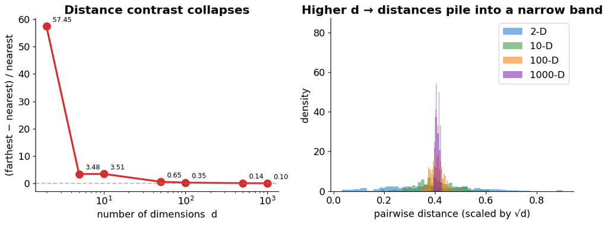

```
At d = 1000, every pair of points is essentially the same distance apart — "nearest neighbour" no longer means anything.
```

## Beyond hand-crafted features

So far every feature has been **hand-designed** — genres, plus the richer columns we sketched (cast, keywords, decade, popularity). Someone has to choose them, label them, and keep them updated. That does not scale.

The real power: turn **any** data into a vector automatically — then reuse the *exact same* similarity tools.

| Data | How it becomes a vector |
| --- | --- |
| **Text** | bag-of-words / TF-IDF → word & sentence embeddings |
| **Images** | pixel features → CNN embeddings |
| **Tabular** | the columns already *are* the vector |
| **Anything** | a learned embedding model |

Once everything is a vector, *similarity is similarity*.

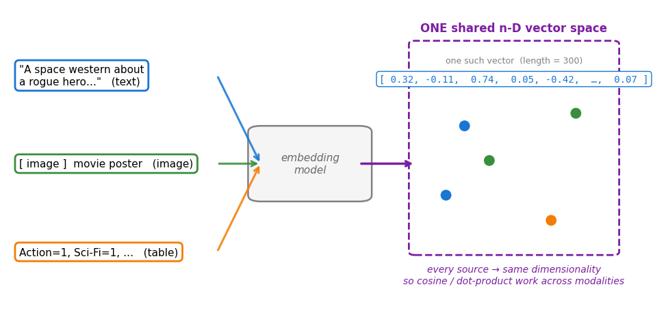

## Step 1: Bag-of-Words — count the words, drop the order

The simplest way to turn text into a vector: pick a **vocabulary**, then for every document count how often each vocabulary word appears.

| document | *space* | *rebels* | *empire* | *romance* | *iceberg* |
| --- | --- | --- | --- | --- | --- |
| "*space rebels fight an evil empire*" | **1** | **1** | **1** | 0 | 0 |
| "*a romance about a doomed ocean liner that hits an iceberg*" | 0 | 0 | 0 | **1** | **1** |

Every row is now a vector in vocabulary space — and cosine similarity works exactly as before.

**Catch:** "the", "a", "movie" dominate every row → cosine is mostly noise. We need to **down-weight common words** ⤵

## TF-IDF: turning text into vectors

**TF-IDF = Term Frequency × Inverse Document Frequency.** Bag-of-words just counts words; TF-IDF *weights* each count by how informative the word is.

$$\text{tfidf}(t,d) \;=\; \underbrace{\text{tf}(t,d)}_{\substack{\textbf{term frequency:} \\ \text{how often } t \\ \text{appears in doc } d}} \;\times\; \underbrace{\log \dfrac{N}{\text{df}(t)}}_{\substack{\textbf{inverse document frequency:} \\ N = \#\text{ docs in the corpus}, \\ \text{df}(t) = \#\text{ docs containing } t}}$$

- **df(t)** is the **document frequency** — how many of the *N* documents contain *t* at least once.
- Word in **every** doc → df = N → idf = log 1 = **0** (worthless).
- Word in **one** doc → df = 1 → idf = log N (most distinctive).

Then two documents are compared with the **same cosine similarity** as before.

**Practical note: smoothed idf.** scikit-learn (and most modern implementations) use a **smoothed** variant:

$$\text{idf}(t) \;=\; \log \dfrac{N+1}{\text{df}(t)+1} \;+\; 1$$

The `+1` in numerator and denominator pretends there is one extra document containing every term — so an unseen term (df = 0) does not divide by zero, and the trailing `+1` keeps even ubiquitous words from being fully zeroed out (they still get a small weight equal to their tf). Ranking behaviour is essentially the same; only the absolute weights differ. (We use the classical $\log(N/\text{df})$ form above because it makes the intuition cleaner.)

### Intuition: why "the" gets weight 0 and "wormhole" gets a huge one

Pick a tiny corpus of **N = 5** movie blurbs. For any word *t*:

- **tf**(t, d) — how often *t* appears in document *d*
- **df**(t) — how many of the 5 documents contain *t* (its **doc-frequency**)
- **idf**(t) = $\log\bigl(N / df(t)\bigr)$ — **big** when *t* is rare, **0** when *t* is everywhere

| word | df | $\log(5/df)$ | verdict |
| --- | --- | --- | --- |
| *the* | 5 | log(1) = **0** | killed — appears everywhere, useless |
| *romance* | 2 | log(2.5) ≈ **0.92** | discriminating — pairs the love stories |
| *wormhole* | 1 | log(5) ≈ **1.61** | very informative — almost defines that doc |

So a word's weight = **how often it shows up here × how rare it is overall**. Multiply, and informative words dominate the vector.

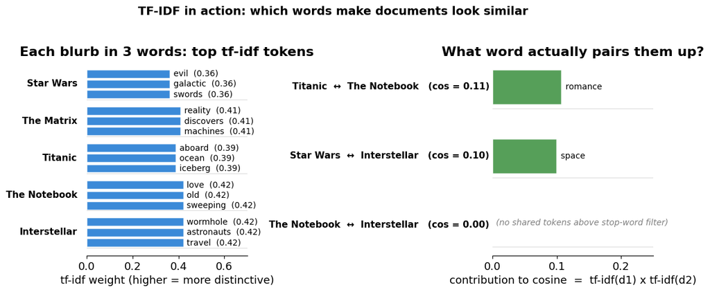

```
Romance pair drives Titanic ↔ Notebook; "space" pairs Star Wars and Interstellar. No genres needed.
```

## Live Demo: TF-IDF in action — "Because you liked..."

The same trick on real MovieLens data: take a richer item vector (genres + tags + decade + popularity, all weighted with TF-IDF) and use cosine similarity to find the nearest — and **furthest** — neighbours.

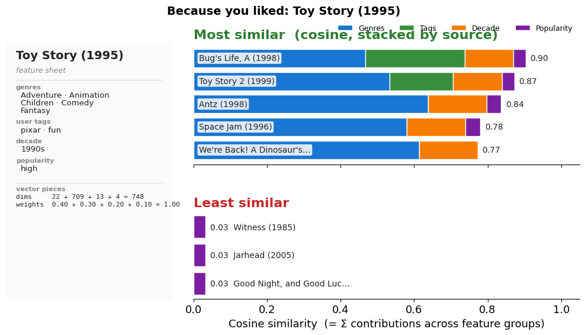

### …and for Forrest Gump

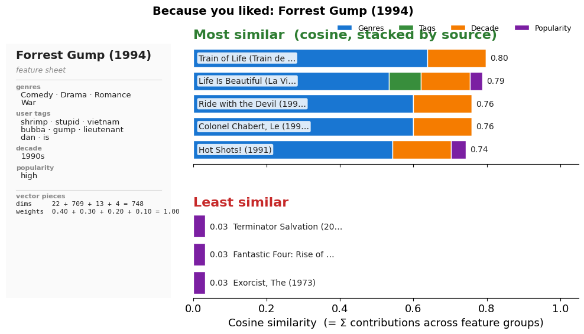

### Where TF-IDF still falls short

TF-IDF only sees **the exact words you wrote**. It misses everything else:

| Problem | Example |
| --- | --- |
| **Synonyms** | "automobile" and "car" treated as unrelated columns |
| **Polysemy** | "bank" (river) vs "bank" (money) collapsed into one weight |
| **Theme vs. words** | A *comedy* and a *horror* both about "space" get a high score |
| **Order & syntax** | "dog bites man" and "man bites dog" produce identical vectors |

The fix: learn a **dense embedding** where direction = meaning (Word2Vec, BERT, sentence transformers). That's the next slide, and the topic of Session 9.

## Word Embeddings: meaning becomes direction

TF-IDF still treats *king* and *queen* as unrelated columns. **Word embeddings** (Word2Vec, GloVe) learn a dense vector per word from huge text corpora, so that **directions carry meaning**.

The famous example:

$$\vec{king} - \vec{man} + \vec{woman} \;\approx\; \vec{queen}$$

The "male → female" step becomes a **consistent direction** anywhere in the space.

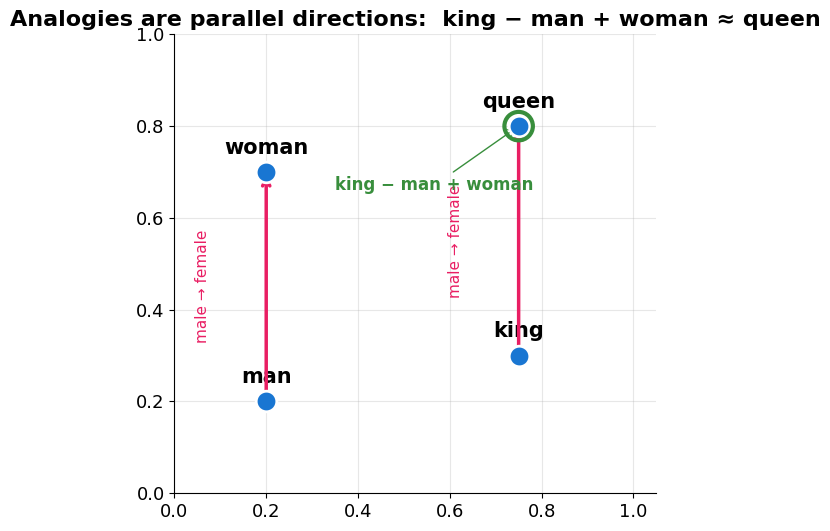

```
(Illustrative layout — the real vectors live in hundreds of dimensions.)
```

### Why embeddings beat TF-IDF: similar wording, different meaning

Three short plot blurbs:

- **Batman** — "a masked **man** fights crime in Gotham city at night"
- **Notting Hill** — "a quiet **man** falls deeply in love with a famous actress in London"
- **The Punisher** — "a brutal vigilante hunts down ruthless criminals across a dark metropolis"

To TF-IDF, the **shared surface word "man"** makes Batman look closer to a romance than to a crime drama. Embeddings know better — they read *meaning*, not letters.

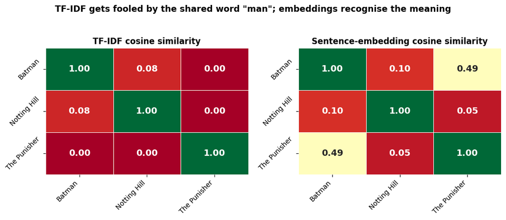

```
TF-IDF says Batman is closer to Notting Hill (0.08) than to The Punisher (0.00).
Embeddings say Batman is closer to The Punisher (0.49) than to Notting Hill (0.10).
```

## The bigger picture: Information Retrieval

> *Information Retrieval (IR) is finding material (usually documents) of an unstructured nature that satisfies an information need from within large collections.* — Manning, Raghavan & Schütze, *Introduction to Information Retrieval* (2008)

A recommender returning "items similar to your profile" is doing exactly this — it is a **search engine whose query is *you***.

That reframing lets us borrow IR's evaluation toolkit: **how good is a ranked list of results?**

## Evaluating a ranked list: Precision & Recall

Label each returned item **relevant** or **not**, then compare to the truth:

|  | relevant | not relevant |
| --- | --- | --- |
| **retrieved** | TP — *True Positive* | FP — *False Positive* |
| **not retrieved** | FN — *False Negative* | TN — *True Negative* |

$$\text{Precision}=\frac{TP}{TP+FP}\qquad\qquad \text{Recall}=\frac{TP}{TP+FN}$$

$$F_1 = \frac{2\,P\,R}{P+R}\qquad(\text{harmonic mean of }P,R)$$

- **Precision** — of what I returned, how much was good?
- **Recall** — of all good items, how many did I find?
- **F₁** — their harmonic mean, handy when balancing both.

Return **more** items → recall rises, precision usually falls. Report metrics **@k** (the top-k items).

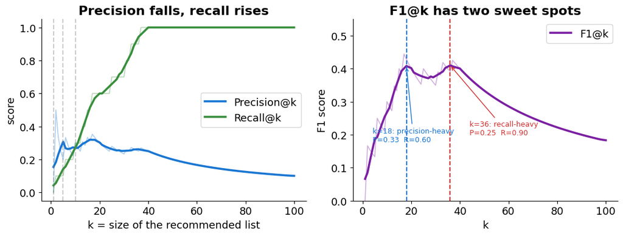

[output not shown]

## Limitations of Content-Based Methods

Even after stacking richer signals — **genres + tags + decade + popularity** in our demo — three structural problems remain:

- **Feature-engineering bottleneck** — every column is a signal someone had to design, label, and maintain. Tags need curators; cast lists need a source like IMDB; missing fields (no tags, no popularity bucket) silently weaken the vector. And TF-IDF still can't tell *car* from *automobile*, no matter how many columns we add.
- **No serendipity** — you only ever get *more of the same*. Aggarwal calls this **over-specialization**: even when a great pick lies in an unfamiliar category (your first Ethiopian restaurant), the recommender keeps proposing variations of what you already know.
- **Curse of dimensionality** — richer features mean huge, sparse vectors where distance metrics blur (cf. the earlier slide on $d \to \infty$).

**Next lecture: matrix factorization.** Drop the hand-designed columns and let the *data* discover which dimensions matter — including the implicit ones (mood, pacing, "feels like a 90s indie") that no tag captures.

### Cold Start: Partially Solved

Content-based methods **can** handle new items — as long as they have features (genres, description, image), we can build a vector and compare.

But **new users** remain a problem: without any ratings, we have no profile vector to match against.

*Remember this — we'll revisit cold start in every remaining lecture.*

## Key Takeaways

1. **Everything becomes a vector** — items, users, text, images — in one shared feature space.
2. **Similarity is geometry:** cosine = angle (ignores length), Euclidean = distance, dot product = both.
3. **Content-based recommending** = match a user-profile vector to item vectors ("because you liked…").
4. **TF-IDF & embeddings** turn unstructured data into vectors automatically — the same similarity tools apply.
5. **Evaluate** a ranked list with Precision@k / Recall@k — it's Information Retrieval.
6. **Cold start:** fine for new *items*, fails for new *users*; plus no serendipity and hand-crafted features don't scale.

**→ Next lecture: Matrix Factorization — let the *data* discover the features.